# Processando a Informação: Cap. 5: Vetores

[figure not shown]

Este caderno (Notebook) é parte complementar *online* do livro **[Processando a Informação](https://editora.ufabc.edu.br/matematica-e-ciencias-da-computacao/58-processando-a-informacao): um livro prático de programação independente de linguagem**, que deve ser consultado no caso de dúvidas sobre os temas apresentados.

> Este conteúdo pode ser copiado e alterado livremente e foi inspirado nesse livro.

## Sumário

- Revisão do capítulo anterior
- Introdução
- Trabalhando com vetores
- Acessando elementos de um vetor
- Formas de percorrer um vetor
- Modularização e vetores
- Eficiência de Algortimos
- Revisão deste capítulo
- Exercícios

## Revisão do capítulo anterior (Estruturas de Repetição - Laços)

- Estruturas de repetição (laços) devem ser utilizadas quando existem instruções que se repentem e podem ser de vários tipos, dependendo da linguagem utilizada, por exemplo:
  - `do-while` (não aceita em Python)
  - `while` (a maioria)
  - `for` (a maioria)
  - `repeat` (R)
- O uso de laços depende da lógica a ser implementada e da linguagem utilizada. Mas, se tiver um número fixo de iterações, geralmente se usa `for`.
- Validação de dados utilizando laços:
  - Incluir um laço para verificar o valor lido.
- Interrupção da execução em laços:
  - Depende da linguagem, algumas possibilidades:
    - `break` - interrompe o laço
    - `continue` - não executa o final do laço
    - `exit` - aborta o laço e o programa!
- Neste capítulo iremos abordar a estrutura de **Vetor**, incluindo os conceitos apresentados nos capítulos anteriores.

## Introdução

- Um **vetor** em programação é formado por um **conjunto de $n$ variáveis de um mesmo tipo** de dado (em geral), sendo $n$ obrigatoriamente maior que zero.
- Essas variáveis (ou elementos) são identificadas e acessadas por um **nome** e um **índice**.
- Na maioria das linguagens de programação, o **índice** recebe valores de $0$ (**primeiro elemento**) até $n-1$ (**último elemento**).
- As variáveis de um vetor são armazenadas em posições consecutivas de memória.

## Trabalhando com vetores

- Quando um vetor é criado, é instanciada uma variável do tipo vetor (em algumas linguagens de programação, sendo necessário se definir um nome, o tipo de dado e o tamanho do vetor).
- Na linguagem C, por exemplo, a definição do tamanho de um vetor ocorre antes de compilar o programa.
  - Ou seja, o programador deverá informar no código a quantidade de memória a ser reservada para o vetor, através de um número inteiro positivo ou constante que o contenha, especificando o número de elementos do mesmo tipo que a memória reservada irá comportar.
  - Neste caso, uma variável não pode ser usada.
- Já na linguagem Java, é possível alocar memória em tempo de execução do programa.
  - Por exemplo, é possível criar um vetor para armazenar as notas de uma turma de alunos, onde o número de alunos é uma variável a ser lida durante a execução do programa.
- Em muitas linguagens, como Java e C, o processo de criar um vetor ocorre em dois passos distintos:
  1. primeiro se cria uma variável de referência para o vetor;
  2. em seguida se reserva a memória para um dado número de elementos do mesmo tipo.
- No exemplo da figura abaixo,
  - a criação da variável de referência de um vetor `v` define apenas a posição de memória em hexadecimal `0A`, onde será armazenado o seu primeiro elemento.
    - neste exemplo, `V[0] = -128` é o primeiro elemento do vetor.
    - a quantidade de `bytes` por elemento vai depender to tipo de dado armazenado. Neste exemplo cada elemento ocupa um `byte`.
  - o segundo passo da criação de um vetor é reservar (ou alocar) memória para todos os seus elementos (dependendo da linguagem).

  > essa alocação de memória pode ocorrer em tempo de execução, como ocorre em Python!

[figure not shown]

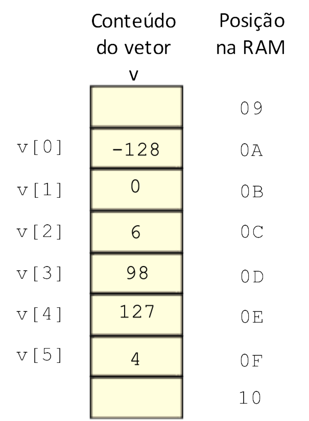

- Note que a variável `v` acima agora se refere a uma posição de memória e não a um elemento de dado.
- Os elementos devem ser acessados através do índice, um por vez.
- Isso pode requerer uso de laços para leitura e impressão dos seus elementos, dependendo da linguagem de programação utilizada.
  - O índice de vetor é sempre um número inteiro.

## Exemplo 01 - Ler/Escrever vetor

#### Pseudocódigo

```
Instanciar o vetor v1 de inteiro com tamanho 5 // ou
vetor v2 = vetor de inteiros com 100 elementos // ou ainda
vetor v3 = inteiro(10)
v1 = {4,1,10,2,3} // atribuindo valores a v1
```

**Exemplo 01:** Ler uma lista com `n` alunos com `RA` e `Nome` e escrever formatando a saída como no exemplo:

```
LISTA DE ALUNOS
Número RA     Nome
1      2134   Maria Campos
2      346    João Silva
```

#### Casos para Teste Moodle+VPL

Para o professor criar uma atividade VPL no Moodle para este Exemplo 01, basta incluir em `Casos para teste`, o seguinte texto (pode incluir mais casos):

```
case=caso1
input=2
2345
9870
Maria Campos
João Silva
output=
LISTA DE ALUNOS
Número RA     Nota
1      2345   Maria Campos
2      9870   João Silva
```

```python
%%writefile cap5ex01.c
#include <stdio.h>

int main(void) {

  // ENTRADA DE DADOS
  int max = 100; // considerar sempre um número grande
  int n, ra[max];     // aloca 100 ra's
  char nome[max][40]; // aloca 100 nomes de até 40 caracteres cada

  printf("Digite o numero de alunos: ");
  scanf("%d", &n);
  for (int i = 0; i < n; i++) {
    printf("RA: ");
    scanf("%d", &ra[i]);
    printf("Nome: ");
    scanf("%s", nome[i]); // ATENÇÃO: NÃO ACEITA NOME COM ESPAÇOS e NÃO USA &
  }
  // PROCESSAMENTO ?
  // SAÍDA
  printf("LISTA DE ALUNOS\nNúmero\t RA\t Nome\n");
  for (int i = 0; i < n; i++) {
    printf("%d\t %d\t %s\n", i + 1, ra[i], nome[i]);
  }
  return 0;
}
```

```python
%%shell
gcc -Wall -std=c99 cap5ex01.c -o output2
./output2
```

- As *strings* em C têm um último caracter `'\0'`. Assim, no exemplo a seguir `s1=s2` tem três carateres cada:
  - `char s1[] = "oi";` ou
  - `char s2[] = {'o','i','\0'};`
- Para ler uma *string* com espaços [[ref](https://www.geeksforgeeks.org/gets-is-risky-to-use)]:

```python
%%writefile cap5ex01teste.c
#include <stdio.h>
#include <string.h>

int main() {
   char s[40];
   printf("digite algo:\n");
   fgets(s, 40, stdin);
   printf("saida: \"%s\" tamanho: %ld\n", s, strlen(s));
   s[strlen(s)-1] = '\0'; // substituir \n por \0
   printf("saida: \"%s\" tamanho: %ld\n", s, strlen(s));
   return 0;
}
```

```python
%%shell
gcc -Wall -std=c99 cap5ex01teste.c -o cap5ex01teste
./cap5ex01teste
```

Algumas funções da biblioteca padrão **string.h**:

| função | descrição |
| --- | --- |
| strcopy(s1,s2) | copia s1 em s2 |
| strcat(s1,s2) | copia s2 no final de s1 |
| strlen(s) | tamanho de s |
| strcmp(s1,s2) | 0 se s1=s2; negativo se s1<s2; positivo se s1>s2 |
| strchr(s,ch) | ponteiro para a primeira ocorrência de ch em s |
| strstr(s1,s2) | ponteiro para a primeira ocorrência de s2 em s1 |

## Formas de Percorrer um Vetor

### Percorrer um vetor com o laço `para`

- Como um vetor, após criado (alocado e com elementos), tem tamanho fixo (sempre com número de elementos `n>0`), geralmente é indicado usar estruturas de repetição do tipo `para` (`for`), de forma a percorrer todos os elementos do vetor
  - assim tornando o código genérico para um vetor de qualquer tamanho `n`.
- Além disso, é natural percorrer (ou varrer) o vetor da posição `i=0` até a posição `i<n`
  - O índice `i` assume automaticamente os valores `0`, `1`, `2`, até `n-1`, em cada iteração do laço.
  - Em algumas linguagens, como Matlab e R, o índice assume valores entre `1` até `n`.
- No exemplo a seguir em pseudocódigo, um vetor `v` é criado com 6 posições e o laço `para` inicializa todos os seus elementos com o valor 0.
- A forma natural de percorrer os elementos de um vertou (ou **varrendo** o vetor) é na ordem **raster**, do primeiro até o último elemento.
- A vantagem de se usar a estrutura `para` para varrer um vertor é permitir embutir na própria sintaxe (linha) da instrução:
  - declaração e inicialização do índice,
  - incremento e
  - condição de saída do laço.

#### Pseudocódigo

```
Instanciar um vetor v de inteiro com 6 elementos (n=6)
para cada indice i, de i=0; até i<n; passo i=i+1 faça
    v[i] = 0
```

### Percorrer um vetor com o laço `enquanto`

- Se o programador preferir, ou o problema a ser resolvido exigir, o vetor pode alternativamente ser percorrido utilizando-se uma estrutura de repetição do tipo `enquanto`:

#### Pseudocódigo

```
n=6
vetor v de inteiros com n elementos
inteiro i=0
enquanto i<n faça {
    v[i] = 0
    i=i+1
}
```

- O código usando a estrutura de repetição `enquanto` produz o mesmo resultado que usando com `para`, porém, usando mais instruções:
  - a criação do contador `i`
  - o incremento `i=i+1`.
- Essas duas instruções ficam encapsuladas na própria instrução `para`.

### Outras formas de percorrer um vetor

- Dependendo do problema a ser tratado, existem várias formas de se varrer um vetor usando estruturas de repetição para acessar cada elemento.
- Por exemplo, é possível percorrer o vetor do último elemento para o primeiro (essa varradora é chamada de **anti-raster**):

#### Pseudocódigo: percorrer um vetor usando para na ordem inversa (**anti-raster**).

[output not shown]

- Também, é possível percorrer somente alguns elementos do vetor, como para acessar os elementos que estão nos índices pares ou ímpares, diferenciadamente:

#### Pseudocódigo: percorrer um vetor usando `para`, com passo 2.

```
vetor v de inteiro com 6 elementos
n=6
para cada indice i, de i=0; até i<n-1; passo i=i+2 faça {
    v[i] = 0
    v[i+1] = 1
}
```

## Modularização e Vetores

- Como uma boa prática de programação, além de comentar os códigos e organizar com tabulação, como apresentado nos exemplos deste livro,
  - também é recomendável modularizar o código usando métodos, como apresentado no Capítulo 2.
- Todo sistema computadorizado de informação possui três partes bem definidas, agrupadas em
  - módulo(s) de entrada,
  - módulo(s) de processamento e
  - módulo(s) de saída.
- Ao manipular informações armazenadas em vetores, é natural criar também pelo menos três módulos ou métodos:
  - `leiaVetor`,
  - `processaVetor` e
  - `escrevaVetor`,

  satisfazendo essa definição de sistema de informação.

> Para a reutilização de código, os módulos `leiaVetor` e `escrevaVetor` poderão ser muito reutilizados para resolver outros problemas de manipulação de vetores.

#### Pseudocódigo: método para ler um vetor de inteiro tamanho n.

```
método leiaVetor(inteiro n): retorna vetor de inteiro v[]
    vetor v de inteiros com n elementos
    para cada índice i, de i=0; até i<n; passo i=i+1 faça
        v[i] = leia("Entre com o elemento " + i + ":");
    retorne v
```

#### Pseudocódigo: método para escrever um vetor de inteiro tamanho n.

```
método escrevaVetor(inteiro v[], inteiro n):
    para cada índice i, de i=0; até i<n; passo i=i+1 faça
        escreva(" " + v[i]);
```

#### Pseudocódigo: aplicação de vetor usando módulos.

```
// Instâncias e Atribuições
inteiro n = leia("Digite o tamanho do vetor:");

// ENTRADA
inteiro v1[] = leiaVetor(n)

// PROCESSAMENTO
// ?

// SAÍDA
escrevaVetor(v2, n)
```

## Exemplo 02 - Aplicação simples 1 usando vetor

Considere um algoritmo para ler a quantidade `n` de alunos de uma turma. Ler uma lista com `n` RA's de alunos. Em seguida, ler também uma lista com `n` notas de alunos. Como saída do algoritmo, escrever a seguinte saída.

```
LISTA DE ALUNOS
Número RA     Nota
1      2134   9
2      346    7
```

Utilizar os métodos `leiaVetor` e `escrevaVetor`, se necessários.

###### Pseudocódigo

```
// ENTRADAS:
// instâncias e atribuições
real media, somador = 0
inteiro contador = 0

// leitura do número de alunos = tamanho do vetor
inteiro n = leia("Digite o número de alunos:");

inteiro ras[] = leiaVetor(n)
inteiro notas[] = leiaVetor(n)

// PROCESSAMENTO
// ?

// SAÍDAS:
escreva("LISTA DE ALUNOS")
escreva("Número RA     Nota")
para cada indice i, de i=0; até i<n; passo i=i+1 faça
    escreva(i+1,"\t",ras[i],"\t",notas[i]
```

#### Casos para Teste Moodle+VPL

Para o professor criar uma atividade VPL no Moodle para este Exemplo 02, basta incluir em `Casos para teste`, o seguinte texto (pode incluir mais casos):

```
case=caso1
input=2
3456
2345
5
2
output=
LISTA DE ALUNOS
Número	 RA	Nota
1 	 3456 	 5
2 	 2345 	 2
```

```python
%%writefile cap5ex02.c
#include <stdio.h>

int main(void) {

  // ENTRADA DE DADOS
  int max = 100; // número máximo de alunos
  int n, ras[max], notas[max];   // variaveis de referência ras e notas

  printf("Digite o numero de alunos: \n");
  scanf("%d", &n);

  printf("RAs: \n");
  for (int i = 0; i < n; i++) {
    printf("RA %d: \n", i + 1);
    scanf("%d", &ras[i]);
  }

  printf("Notas: \n");
  for (int i = 0; i < n; i++) {
    printf("Nota %d: \n", i + 1);
    scanf("%d", &notas[i]);
  }

  // PROCESSAMENTO ?
  // SAÍDA
  printf("LISTA DE ALUNOS\nNúmero\t RA\t Nota\n");
  for (int i = 0; i < n; i++) {
    printf("%d\t %d\t %d\n", i + 1, ras[i], notas[i]);
  }
  return 0;
}
```

```python
%%shell
gcc -Wall -std=c99 cap5ex02.c -o output2
./output2
```

Existem várias formas de usar vetor em métodos:

- como argumento:
  - `void metodo (int *v, int n) {...}`
  - `void metodo (int v[], int n) {...}`
  - `void metodo (int v[max], int n) {...}`
- como retorno:
  - `int * metodo (int n) {...}` - alocar vetor dentro do método, alocação dinâmica de memória, com `malloc` ou `calloc`.
  - não esquecer de liberar a memórica com `free`.

```python
%%writefile cap5ex02teste1.c
#include <stdio.h>

#define MAX_ALUNOS 20 // número máximo de alunos

void leiaVetor(int *v, int n) {
  for (int i = 0; i < n; i++)
    scanf("%d", &v[i]);
}

int main(void) {

  // ENTRADA DE DADOS
  int n, ras[MAX_ALUNOS], notas[MAX_ALUNOS];   // variaveis de referência ras e notas

  printf("Digite o numero de alunos: \n");
  scanf("%d", &n);

  printf("RAs: \n");
  leiaVetor(ras, n);

  printf("Notas: \n");
  leiaVetor(notas, n);

  // PROCESSAMENTO ?
  // SAÍDA
  printf("LISTA DE ALUNOS\nNúmero\t RA\t Nota\n");
  for (int i = 0; i < n; i++)
    printf("%d\t %d\t %d\n", i + 1, ras[i], notas[i]);

  return 0;
}
```

```python
%%shell
gcc -Wall -std=c99 cap5ex02teste1.c -o output2
./output2
```

```python
%%writefile cap5ex02teste2.c
#include <stdio.h>
#include <stdlib.h>  // malloc e free

int * leiaVetor(int n) {
  int *v= malloc(sizeof(n));  // ALOCAÇÃO DINÂMICA
  for (int i = 0; i < n; i++) {
    scanf("%d", &v[i]);
  }
  return v;
}

int main(void) {

  // ENTRADA DE DADOS
  int n, *ras, *notas;   // variaveis de referência ras e notas

  printf("Digite o numero de alunos: ");
  scanf("%d", &n);

  printf("RAs: ");
  ras = leiaVetor(n);

  printf("Notas: ");
  notas = leiaVetor(n);

  // PROCESSAMENTO ?
  // SAÍDA
  printf("LISTA DE ALUNOS\nNúmero\t RA\t Nota\n");
  for (int i = 0; i < n; i++) {
      printf("%d\t %d\t %d\n",i+1, ras[i],notas[i]);
  }
  free(ras);   // LIBERAR MEMÓRIA ALOCADA COM malloc
  free(notas);
  return 0;
}
```

```python
%%shell
gcc -Wall -std=c99 cap5ex02teste2.c -o output2
./output2
```

## Exemplo 03 - Aplicação simples 2 usando vetor

Considere um algoritmo para ler a quantidade `n` de alunos de uma turma. Ler também uma lista com `n` notas de alunos. Como saída do algoritmo, escrever a média da turma e quantos alunos ficaram acima da média.

###### Pseudocódigo

```
// ENTRADAS:
// instâncias e atribuições
real media, somador = 0
inteiro contador = 0

// leitura do número de alunos = tamanho do vetor
inteiro n = leia("Digite o número de alunos:");

inteiro ras[] = leiaVetor(n)
real notas[] = leiaVetor(n)

// PROCESSAMENTO: soma, média e contador
para cada indice i, de i=0; até i<n; passo i=i+1 faça
    somador = somador + notas[i] // soma
media = somador / n   // média
para cada indice i, de i=0; até i<n; passo i=i+1 faça
    se ( notas[i] >= media ) // conta alunos>=media
        contador = contador + 1

// SAÍDAS:
escreva("Média da turma=" + media) // Saída
escreva("Alunos acima da média: " + contador)
escreva("LISTA DE ALUNOS ACIMA DA MÉDIA")
escreva("RA\t Nota")
para cada indice i, de i=0; até i<n; passo i=i+1 faça
  se (nota[i] >= media)
    escreva(ras[i],"\t",notas[i]
```

#### Casos para Teste Moodle+VPL

Para o professor criar uma atividade VPL no Moodle para este Exemplo 03, basta incluir em `Casos para teste`, o seguinte texto (pode incluir mais casos):

```
case=caso1
input=2
233245
234534
9
4
output=
Média da turma = 6.5
Número de alunos acima da média = 1
LISTA DE ALUNOS ACIMA DA MÉDIA
RA      Nota
233245  9
```

```python
%%writefile cap5ex03.c
#include <stdio.h>
#include <stdlib.h>

int * leiaVetor(int n) {
  int *v= malloc(sizeof(n));
  for (int i = 0; i < n; i++) {
    scanf("%d", &v[i]);
  }
  return v;
}

int main(void) {

  // ENTRADA DE DADOS
  int n, *ras, *notas;   // variaveis de referência ras e notas
  float media,somador = 0.0;
  int contador = 0;

  printf("Digite o numero de alunos: ");
  scanf("%d", &n);

  printf("RAs: ");
  ras = leiaVetor(n);

  printf("Notas: ");
  notas = leiaVetor(n);

  // PROCESSAMENTO: soma, média e contador
  for (int i = 0; i < n; i++) {
      somador = somador + notas[i];   // soma
  }
  media = (float) somador / n;            // média

  for (int i = 0; i < n; i++) {
      if (notas[i] >= media) {        // conta alunos>=media
          contador = contador + 1;
      }
  }
  // SAÍDA DE DADOS
  printf("Média da turma = %.1f\n",media);
  printf("Número de alunos acima da média = %d\n",contador);
  printf("LISTA DE ALUNOS ACIMA DA MÉDIA\nRA\t Nota\n");
  for (int i = 0; i < n; i++) {
    if (notas[i] >= media) {        // conta alunos>=media
      printf("%d\t %d\n",ras[i],notas[i]);
    }
  }
  free(ras);  // liberar memória alocado com malloc
  free(notas);
  return 0;
}
```

```python
%%shell
gcc -Wall -std=c99 cap5ex03.c -o output2
./output2
```

## Exemplo 04 - Aplicação "dilata" vetor

- O programador deve tomar cuidado ao acessar os elementos de um vetor para **não ultrapassar os seus limites alocados previamente**, ou seja,
  - para um vetor `v` de tamanho `n`, índices `i` com `i<0` ou `i>=n` não existem.
- O exemplo a seguir ilustra este problema.
- Considere o problema de "**dilatar**" um vetor.
  - O objetivo é criar um vetor `v1` de inteiros com `n` posições e um outro vetor `v2` de inteiros também com `n` posições.
  - Cada posição `i` de `v2` armazena o cálculo do **máximo** entre cada elemento `i` em `v1` e seus vizinhos:
    1. à esquerda `v1[i-1]`,
    2. do próprio elemento `v1[i]` e
    3. do seu vizinho à direita `v1[i+1]`.
- Veja uma ilustração da operação de dilatação na Figura abaixo, onde `v1` é o vetor de entrada e `v2` é o vetor de saída, contendo a "dilatação" de `v1`, seguido do código para resolver este problema proposto.

[figure not shown]

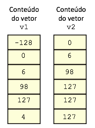

###### Pseudocódigo

```
método escrevaVetor(inteiro v[], inteiro n):
    para cada índice i, de i=0; até i<n; passo i=i+1 faça
        escreva(" " + v[i]);

método leiaVetor(inteiro n): retorna vetor de inteiro v[]
    vetor v de inteiros com n elementos
    para cada índice i, de i=0; até i<n; passo i=i+1 faça
        v[i] = leia("Entre com o elemento " + i + ":");
    retorne v

// Inicializações
inteiro max=0
// ENTRADA
inteiro n = leia("Digite o tamanho do vetor:");
vetores v1 e v2 de inteiros com n elementos

inteiro v1[] = leiaVetor(n)

// PROCESSAMENTO
para cada índice i, de i=0; até i<n; passo i=i+1 faça
    max = v[i]
    se i-1 >= 0 e max < v1[i-1] faça
        max = v1[i-1]
    se i+1 < n e max < v1[i+1] faça
        max = v1[i+1]
    v2[i] = max

// SAÍDA
escrevaVetor(v2)
```

#### Casos para Teste Moodle+VPL

Para o professor criar uma atividade VPL no Moodle para este Exemplo 04, basta incluir em `Casos para teste`, o seguinte texto (pode incluir mais casos):

```
case=caso1
input=6
-128
0
6
98
127
4
output=v2:
0
6
98
127
127
127
```

```python
%%writefile cap5ex04.c
#include <stdio.h>
#include <stdlib.h>  // malloc e free

int * leiaVetor(int n) {
  int *v = malloc(n*sizeof(int));
  for (int i = 0; i < n; i++) {
    scanf("%d", &v[i]);
  }
  return v;
}
void escrevaVetor(int *v, int n) {
  for (int i = 0; i < n; i++) {
    printf("%d\n", v[i]);
  }
}
int main(void) {
  // ENTRADA DE DADOS
  int n, *v1;   // variaveis de referência v1
  printf("Digite o tamanho do vetor: ");
  scanf("%d", &n);
  int *v2 = malloc(100*sizeof(int));
  printf("Digite os elementos: ");
  v1 = leiaVetor(n);
  // PROCESSAMENTO
  for (int i = 0; i < n; i++) {
    int max = v1[i];
    if (i-1 >= 0 && max < v1[i-1])
        max = v1[i-1];
    if (i+1 < n && max < v1[i+1])
        max = v1[i+1];
    v2[i] = max;
  }
  // SAÍDA:
  printf("\nv2:\n");
  escrevaVetor(v2,n);
  free(v1); // liberar memória alocado com malloc
  free(v2);
  return 0;
}
```

```python
%%shell
gcc -Wall -std=c99 cap5ex04.c -o output2
./output2
```

## Eficiência de Algoritmo

A eficiência de um código (ou melhor, de um algoritmo) se mede analisando (ou contando) o número de instruções executadas.

Este tipo de análise de complexidade é útil quando temos uma grande quantidade de dados a serem processados.

Assim, um algoritmo mais eficiente (com menos passos) resolve um mesmo problema mais rápido. Imagine, por exemplo, que uma simulação física em tempo real é bem melhor que uma que leva várias horas para gerar resultados. Apesar de ser desejável medir a eficiência de um algoritmo considerando a medida de tempo, esta medida depende do sistema utilizado (hardware).

Para resolver isto, a análise da complexidade de algoritmo se mede através da contagem do número de instruções executadas.

Para simplificar a contagem, podemos considerar apenas algumas instruções, como a quantidade de algumas condições lógicas.

### Busca

Por exemplo, considerando um algoritmo para buscar um elemento $x$ em um vetor de inteiros com $n$ elementos, temos, no melhor caso, apenas uma instrução, considerando que o elemento $x$ está na primeira posição do vetor.

Neste caso dizemos que o algoritmo de busca possui uma complexidade assintótica1 de melhor caso $\Omega(1)$, ou complexidade constante (notação Bachmann–Landau, assintótica ou, como é mais conhecida, Big-O notation).

Verifique o teste de mesa a seguir considerando um vetor $v$ com 5 elementos, contendo valores de 1 a 5, e considerando também que $x=1$.

|  | Função Busca(int vet, int n, int x) | i | v[i] | Busca(v,5,1) |
| --- | --- | --- | --- | --- |
| 1 | para i=0; i < n; i++ | 0 |  |  |
| 2 | _ se v[i]==x |  | 1 |  |
| 3 | _ _ retorne i |  |  | 0 |
| 4 | retorne -1 |  |  |  |
|  | **Valores finais** |  |  | 0 |

Por outro lado, este algoritmo de busca tem no pior caso n instruções de comparação, ou seja, se $x=5$, a instrução na linha 2 será executada 5 vezes. Neste caso, dizemos que o algoritmo de busca tem complexidade assintótica de pior caso $O(n)$, ou complexidade linear.

Quando $\Omega(n)=O(n)$, então dizemos que é um algoritmo ótimo, ou $\Theta(n)$ (da ordem de $n$).

Por exemplo, considere o algoritmo buscaMaior que encontra o maior elemento de um vetor de tamanho n. Neste caso, o algoritmo buscaMaior tem complexidade assintótica $\Theta(n)$.

|  | Função buscaMaior(int vet, int n) | Número de instruções |
| --- | --- | --- |
| 1 | int maior = v[0] | 1 |
| 2 | para i=1; i< n; i++ | n-1 |
| 3 | _ se maior < v[i] | n-1 |
| 4 | _ _ maior = v[i] | < n-1 |
| 5 | retorne maior | 1 |
|  | **Complexidade** | $f(n) <= 3n-1 = \Theta(n)$ |

A contagem do número de instruções pode ser realizada de forma simplificada somando todas as instruções que aparecem na última coluna da tabela anterior, assim $f(n) <= 1 + n-1 + n-1 + n-1 + 1 = 2 + 3(n-1) = 3n -1 <= kn$, para algum $k>=3$. Ou simplesmente, $f(n) = O(n)$. Como para este algoritmo de busca do maior elemento, o melhor caso também é linear, ou seja, $\Omega(n)$. Podemos afirmar então que este algoritmo de busca é ótimo, ou seja, $\Theta(n)$.

### Ordenação

Algoritmos muito estudados em análise assintótica são os de ordenação, para deixar os valores de um vetor com n elementos em ordem crescente ou decrescente. Considere o seguinte algoritmo de ordenação, chamado **Bubble Sort**.

Veja uma simulação do algoritmo **Bubble Sort** com lego em: https://youtu.be/MtcrEhrt_K0.

Veja a comparação de vários algoritmos de ordenação em: https://youtu.be/ZZuD6iUe3Pc.

Ver também:

- https://pt.wikipedia.org/wiki/Bubble_sort
- https://pt.wikipedia.org/wiki/Selection_sort
- https://pt.wikipedia.org/wiki/Insertion_sort

|  | Função ordena(int vet, int n) | Número de instruções |
| --- | --- | --- |
| 1 | para i=0; i<n; i++ | n |
| 2 | _ para j=0; j<n; j++ | n*n |
| 3 | _ _ se v[i] > v[j] | n*n |
| 4 | _ _ _ int aux = v[i] | < n*n |
| 5 | _ _ _ v[i] = v[j] | < n*n |
| 6 | _ _ _ v[j] = aux | < n*n |
| 7 | retorne v | 1 |
|  | **Complexidade** | $f(n) = n*n = O(n^2)$ |

A complexidade assintótica de algoritmo considera o seu comportamento com um valor grande de dados a serem processados ($n$ grande) e é abordado com detalhes em literaturas mais avançadas de programação.

Existem vários algoritmos de ordenação com diferentes ordens de complexidade, porém é possível se provar matematicamente que o mais eficiente entre eles não poderá ser melhor que $\Omega(n*log \ n)$.

|  | Função ordena2(int vet, int n) | Número de instruções |
| --- | --- | --- |
| 1 | para i=0; i < n-1; i++ | n-1 |
| 2 | _ para j=i+1; j < n; j++ | n+n-1+n-2+...+1 |
| 3 | _ _ se v[i] > v[j] | n+n-1+n-2+...+1 |
| 4 | _ _ _ int aux = v[i] | < n+n-1+n-2+...+1 |
| 5 | _ _ _ v[i] = v[j] | < n+n-1+n-2+...+1 |
| 6 | _ _ _ v[j] = aux | < n+n-1+n-2+...+1 |
| 7 | retorne v | 1 |
|  | ** Complexidade ** | $f(n) = n*n/2 = O(n^2)$ |

## Exercícios

Ver notebook Colab nos arquivos `cap5.partX.lab.*.ipynb` (`X` $\in$ `[2,3]` e `*` é a extensão da linguagem), utilizando alguma linguagem de programação de sua preferência, organizadas em subpastas contidas de `"gen"`, na pasta do Google Drive [colabs](https://drive.google.com/drive/folders/1YlFwv8XYN7PYYf-HwDMlkxzbmXzJw9cM?usp=sharing).

## Atividades no Moodle+VPL

Algumas atividades no Moodle+VPL pedem como entradas vetores de inteiros (ou reais), **armazenados em uma única linha**. Exemplo de entrada a ser lida:

### Entrada de Dados (cada linha contem um texto ou *string* incluindo os elementos do vetor e vários espaços ""):

```
7 3 7 9 7 7 0 9 8 4 8 9 0 1 7 8 4 1 1 0
2 1 9 4 3 6 0 9 8 4 2 8 0 6 7 3 2 4 5 9
```

Para não ter que incluir várias entradas inteiras, uma por linha, uma solução é fazer um método de leitura, passando como argumento um texto (*string*) referente a cada linha. Esse método deve retornar o vetor.

```python
%%writefile str2int.c
#include <stdio.h>
#include <string.h>
#include <stdlib.h>
int MAX=100, tamanho = 0;
void leiaVetor(int v[MAX], char string[]) {
   char * token = strtok(string, " ");
   while( token != NULL ) {
      v[tamanho++] = atoi(token); // converte texto para inteiro
      token = strtok(NULL, " ");
   }
}
int main() {
   char string[] = "7 3 7 9 7 7 0 9 8 4 8 9 0 1     7 8 4 1 1 0     ";
   int v[MAX];
   leiaVetor(v, string);
   for (int i=0;i<tamanho;i++ ){
     printf("%d ",v[i]);
   }
   return 0;
}
```

```python
%%shell
gcc -Wall -std=c99 str2int.c -o output2
./output2
```

```python
%%writefile str2int.c
#include <stdio.h>
#include <string.h>
#include <stdlib.h>
int tamanho = 20;
// método para ler um vetor de inteiros digitado em uma linha, separados por espaços
int* leiaVetor(int n) {
  int* v = malloc(n * sizeof(int)); // aloca um vetor de n inteiros
  char texto[512]; // espaço para todos os números como um texto
  scanf("%[^\n]", texto); // lê todos os números como um texto
  char* token = strtok(texto, " "); // lê até o primeiro espaço na variável token
  int i = 0;
  while (token != NULL && i < n) {
    v[i++] = atoi(token); // guarda o valor convertido em numero no vetor e avança
    token = strtok(NULL, " "); // lê até ao próximo espaço a partir de onde terminou
  }
  return v;
}
int main() {
   //char string[] = "7 3 7 9 7 7 0 9 8 4 8 9 0 1     7 8 4 1 1 0     ";
   int * v = leiaVetor(tamanho);
   for (int i=0;i<tamanho;i++ ){
     printf("%d ",v[i]);
   }
   free(v); // libera memória alocada com malloc
   return 0;
}
```

```python
%%shell
gcc -Wall -std=c99 str2int.c -o output2
./output2
```

### Entrada de Dados (a linha contem um texto ou *string*):

```
A UFABC completou 15 anos!
```

Como contar as vogais de um texto?

## Revisão deste capítulo de Vetores

- Introdução

  > Vetores são estruturas para armazenar vários elementos de um mesmo tipo de dados em uma única variável.
- Trabalhando com vetores

  > Cada linguagem possui uma sintaxe própria para declarar e alocar vetores.
- Acessando elementos de um vetor

  > ATENÇÃO para não acessar uma posição do vetor não reservada/alocada, geralmente `<0` e `>=n`.
- Formas de percorrer um vetor

  > É possível varrer um vetor na forma ***raster*** e ***anti-raster***, também usando diferentes passos, mas geralmente é passo=1.
- Modularização e vetores

  > Muito útil usar principalmente os módulos de `leiaVetor` e `escrevaVetor`, podendo ser reaproveitados em vários códigos.
- Eficiência de Algortimos

  > Busca

  > Ordenação
- Exercícios
- Revisão deste capítulo de Vetores